# Spatial Analysis with inlabru

## Load libraries

```r
library(sf)
library(INLA)
library(inlabru)
library(fmesher)
library(raster)
library(mgcv)
library(ggplot2)
library(terra)
bru_safe_sp(force = TRUE)
```

## Read the data

We first start by reading the for the point patterns, the boundaries and external boxes of all the cells in the data base as *sf* objects and then we read the covariate images as *terra raster* objects.

```r
all.peroxisomes <- st_read("../../data/processed/VERO/peroxisomes.geojson",crs = NA)
all.boundaries <- st_read("../../data/processed/VERO/domain.geojson",crs = NA)
all.meshboxes <- st_read("../../data/processed/VERO//meshbox.geojson",crs = NA)
rast.mt <- rast("../../data/processed/VERO/mitochondria.tif")
rast.er <- rast("../../data/processed/VERO/er.tif")
rast.nd <- rast("../../data/processed/VERO/nucleus_distance.tif")
rast.fd <- rast("../../data/processed/VERO/fractional_distance.tif")
```

Let’s inspect our data set,

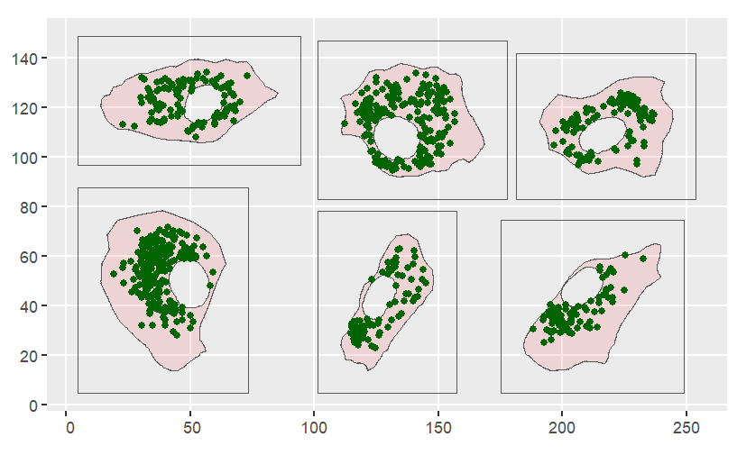

```r
ggplot() +
  gg(all.meshboxes, alpha = 0) +
  gg(all.boundaries, fill ="red",alpha = 0.1) +
  gg(all.peroxisomes,color = "darkgreen")
```

## Choose cells for the analysis

The data set consists of 6 cells, from those 6 we can make a choice on which will be used for the inference by filtering them out through the data set, here we will use all the cells in the data-set

```r
cell_indx <- c(1,2,3,4,5,6)

boundary <- all.boundaries[cell_indx, ]

meshboxes <- all.meshboxes[cell_indx, ]

inside.indx <- apply(st_intersects(all.peroxisomes, boundary, sparse = FALSE),1, function(x) any(x))
peroxisomes <- all.peroxisomes[inside.indx, ]
```

This filtering is not necessary for the covariate objects as the for the analysis they are sampled based on location therefore the regions needed will be sampled correctly as long as the objects stay aligned.

A nessesary step in spatial analysis with INLA is the construction of a mesh for the domain, and an external mesh which is necessary to avoid artificial boundary effects on the random field.

In the construction of the mesh, we choose the maximum length for the edges of the mesh triangles to be 1um as this is the resolution for the size of our covariate components. The maximum edge length for the outer mesh is set at 4um. Last we set a cutoff/minimum length for the edge length to be 0.2 as very small triangles can lead to numerical problems down the line of the analysis.

```r
mesh <- fm_mesh_2d_inla(boundary = list(boundary,meshboxes), max.edge = c(1, 4),cutoff = 0.2)
```

We can plot everything to check that the mesh and the points (and other objects) are as expected

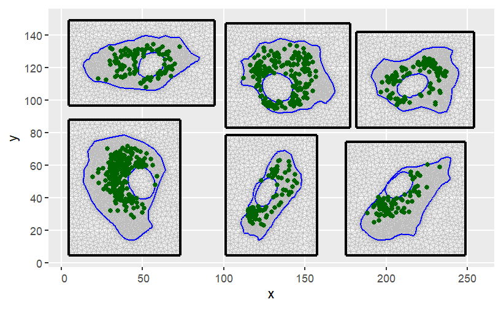

```r
ggplot() +
  gg(mesh, fill ="red",alpha = 0.1) +
  gg(peroxisomes,color = "darkgreen")
```